# Outcrossing Populations

## Genetic mapping of linkage group 3 (with reference genome information)

```r
# CHR3_frame <- mds_onemap(CHR_mks$sequences$CHR3)
# or
CHR3_ord <- order_seq(CHR_mks$sequences$CHR3)
CHR3_frame <- make_seq(CHR3_ord, "force")
```

```r
rf_graph_table(CHR3_frame, mrk.axis = "numbers") # graphic not shown
```

Here, marker `29` has a color pattern too different from the expected, removing it could be influential in other markers ordering. Then we will remove them and search for a new order.

```r
CHR3_test_seq <- drop_marker(CHR3_frame, c(29))
CHR3_test_ord <- order_seq(CHR3_test_seq)
CHR3_test_map <- make_seq(CHR3_test_ord, "force")
```

```r
rf_graph_table(CHR3_test_map, mrk.axis = "numbers") #graphic not shown
```

Trying to add marker `29` again.

```r
CHR3_add29_seq <- try_seq(CHR3_test_map, 29)
CHR3_add29 <- make_seq(CHR3_add29_seq, 12) # Marker 29 increase the map size disproportionately, it was removed from the map
```

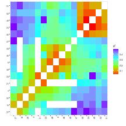

```r
CHR3_final <- CHR3_test_map
rf_graph_table(CHR3_final, inter = FALSE)
```

Checking for better orders:

```r
ripple_seq(CHR3_final)
```

```
#> 27-16-20-4-|-21-... OK
#>
#> ...-27-|-16-20-4-21-|-23-... OK
#>
#> ...-16-|-20-4-21-23-|-48-...
#>   Alternative orders:
#>   ... 16 20 4 21 23 48 ... :    0.00 ( linkage phases: ... 1 2 2 1 1 ... )
#>   ... 16 20 4 23 21 48 ... :   -2.27 ( linkage phases: ... 1 2 2 1 1 ... )
#>
#> ...-20-|-4-21-23-48-|-9-...
#>   Alternative orders:
#>   ... 20 4 21 23 48 9 ... :    0.00 ( linkage phases: ... 2 2 1 1 1 ... )
#>   ... 20 4 23 21 48 9 ... :   -2.27 ( linkage phases: ... 2 2 1 1 1 ... )
#>
#> ...-4-|-21-23-48-9-|-46-...
#>   Alternative orders:
#>   ... 4 21 23 48 9 46 ... :    0.00 ( linkage phases: ... 2 1 1 1 1 ... )
#>   ... 4 23 21 48 9 46 ... :   -2.27 ( linkage phases: ... 2 1 1 1 1 ... )
#>
#> ...-21-|-23-48-9-46-|-45-...
#>   Alternative orders:
#>   ... 21 23 48 9 46 45 ... :    0.00 ( linkage phases: ... 1 1 1 1 1 ... )
#>   ... 21 23 48 46 9 45 ... :   -1.00 ( linkage phases: ... 1 1 1 1 1 ... )
#>
#> ...-23-|-48-9-46-45-|-47-...
#>   Alternative orders:
#>   ... 23 48 9 46 45 47 ... :    0.00 ( linkage phases: ... 1 1 1 1 1 ... )
#>   ... 23 48 46 9 45 47 ... :   -1.00 ( linkage phases: ... 1 1 1 1 1 ... )
#>   ... 23 48 45 9 46 47 ... :   -1.67 ( linkage phases: ... 1 1 1 1 1 ... )
#>
#> ...-48-|-9-46-45-47-|-50-...
#>   Alternative orders:
#>   ... 48 9 46 45 47 50 ... :    0.00 ( linkage phases: ... 1 1 1 1 2 ... )
#>   ... 48 46 9 45 47 50 ... :   -1.00 ( linkage phases: ... 1 1 1 1 2 ... )
#>   ... 48 45 9 46 47 50 ... :   -1.67 ( linkage phases: ... 1 1 1 1 2 ... )
#>
#> ...-9-|-46-45-47-50-|-24-... OK
#>
#> ...-46-|-45-47-50-24-|-49-... OK
#>
#> ...-45-|-47-50-24-49-|-52-... OK
#>
#> ...-47-|-50-24-49-52-|-51-...
#>   Alternative orders:
#>   ... 47 52 49 24 50 51 :    0.00 ( linkage phases: ... 2 1 1 1 1 )
#>   ... 47 50 24 49 52 51 :   -0.34 ( linkage phases: ... 2 1 1 1 1 )
#>   ... 47 49 52 24 50 51 :   -2.59 ( linkage phases: ... 2 1 1 1 1 )
#>
#> 50-|-24-49-52-51
#>   Alternative orders:
#>   ... 50 24 49 52 51 :    0.00 ( linkage phases: ... 1 1 1 1 )
#>   ... 50 24 52 49 51 :   -2.76 ( linkage phases: ... 1 1 1 1 )
```

# Drawing the genetic maps

Once all linkage groups were obtained using both strategies, we can draw a map for each approach using the function `draw_map`. Since version 2.1.1007, `OneMap` has a new version of `draw_map`, called `draw_map2`. The new function draws elegant linkage groups and presents new arguments to personalize your draw.

If you prefer the old function, we also keep it. Follow examples on how to use both of them.

## Draw_map

Drawing the map, which was built with only recombinations information.

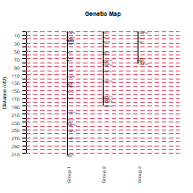

```r
map1 <- list(LG1_final, LG2_final, LG3_final)
draw_map(map1, names = TRUE, grid = TRUE, cex.mrk = 0.7)
```

Drawing the map, which built with reference genome and recombinations information

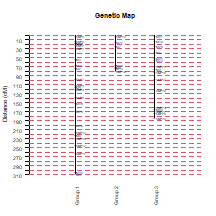

```r
map2 <- list(CHR1_final, CHR2_final, CHR3_final)
draw_map(map2, names = TRUE, grid = TRUE, cex.mrk = 0.7)
```

We also can draw maps comparing corresponding linkage groups in each strategy:

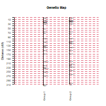

```r
CHR1_comp <- list(LG1_final, CHR1_final)
draw_map(CHR1_comp, names = TRUE, grid = TRUE, cex.mrk = 0.7)
```

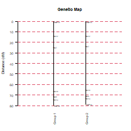

```r
CHR2_comp <- list(LG3_final, CHR2_final)
draw_map(CHR2_comp, names = TRUE, grid = TRUE, cex.mrk = 0.7)
```

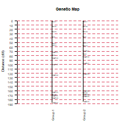

```r
CHR3_comp <- list(LG2_final, CHR3_final)
draw_map(CHR3_comp, names = TRUE, grid = TRUE, cex.mrk = 0.7)
```

Or groups alone:

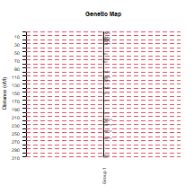

```r
draw_map(CHR1_final, names = TRUE, grid = TRUE, cex.mrk = 0.7)
```

Function `draw_map` draws a straightforward graphic representation of the genetic map. More recently, we developed a new version called `draw_map2` that brings a more sophisticated figure. Furthermore, once the distances and the linkage phases are estimated, other map figures can be drawn by the user with any appropriate software. There are several free software that can be used, such as `MapChart` (Voorrips, 2002).

## Draw_map2

Drawing the map, which was built with only recombinations information:

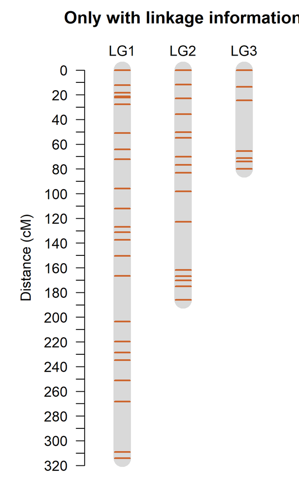

```r
draw_map2(LG1_final, LG2_final, LG3_final, main = "Only with linkage information",
          group.names = c("LG1", "LG2", "LG3"))
```

The figure will be saved in your work directory with the default name `map.eps`. You can change the file name and extension specifying them in the argument `output`.

Drawing the map, which was built with reference genome and recombinations information

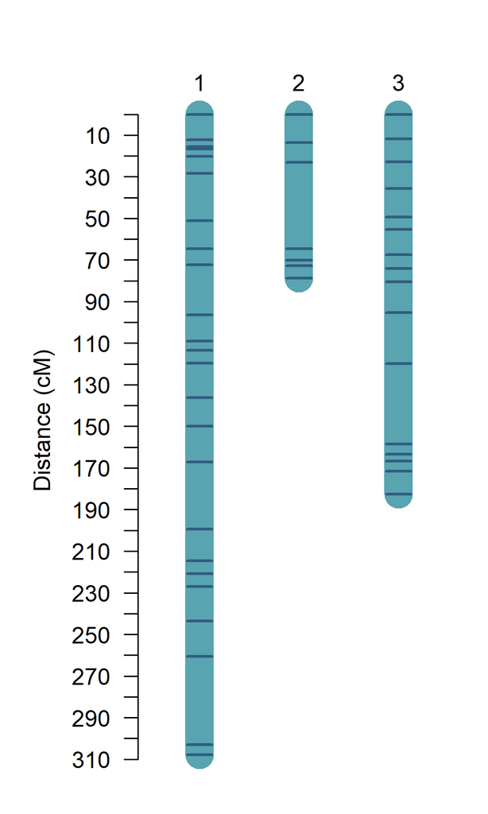

```r
draw_map2(CHR1_final, CHR2_final, CHR3_final, output= "map_ref.pdf",
          col.group = "#58A4B0",
          col.mark= "#335C81")
```

With the argument `tag`, we can highlight some markers with other colors. The arguments `col.group`, `col.mark` and `col.tag` can be changed to personalize the color of the groups, the markers, and the highlighted markers, respectively.

We also can draw maps comparing corresponding linkage groups in each strategy:

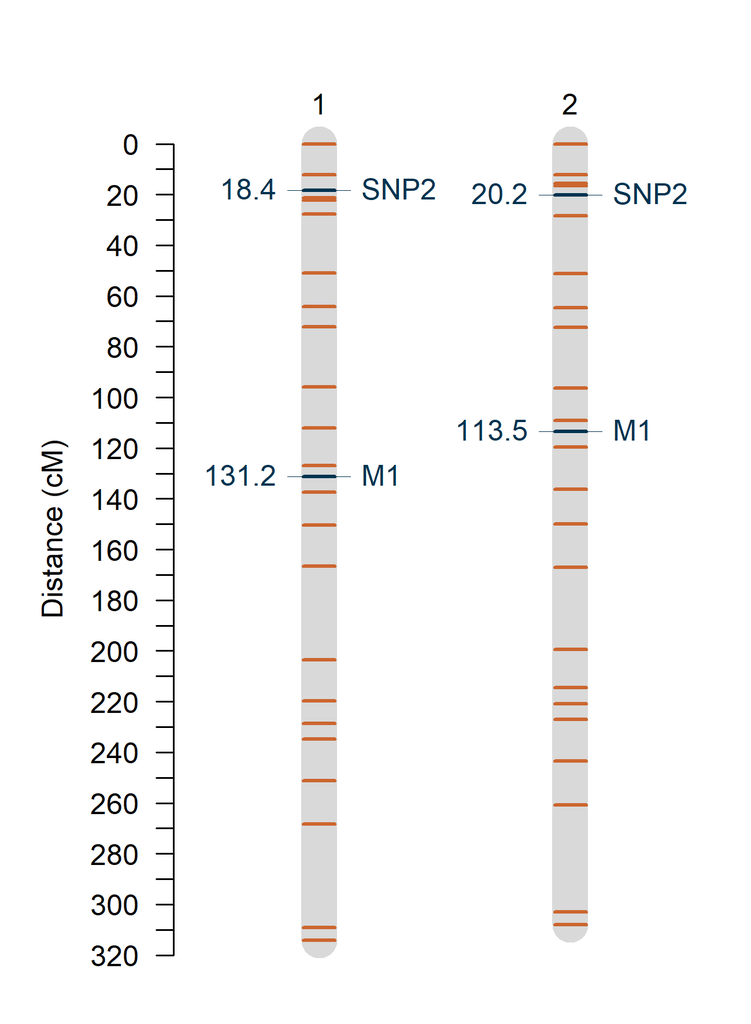

```r
draw_map2(LG1_final, CHR1_final, output = "map_comp.pdf", tag = c("M1","SNP2"))
```

When defining marker names in the `tag` argument, all markers with these names will be highlighted no matter in which group it/they is/are.

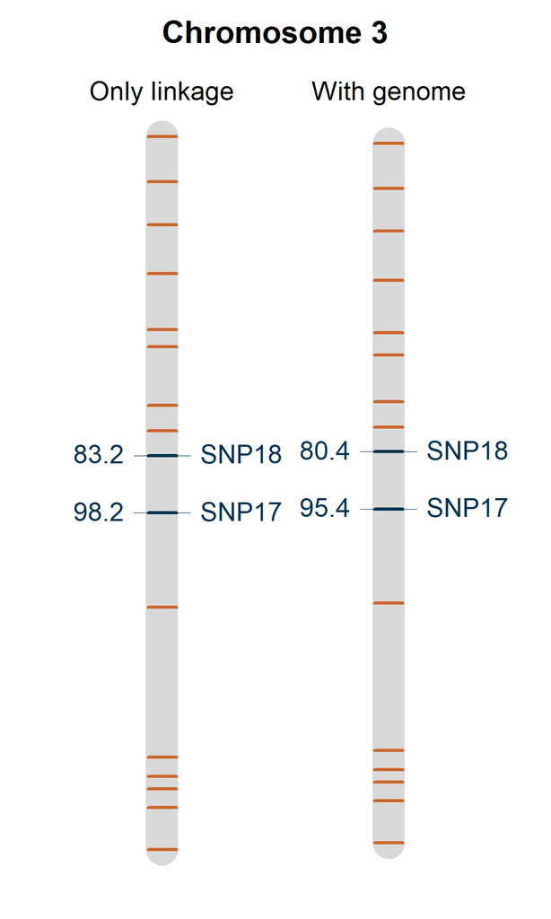

```r
draw_map2(LG2_final, CHR3_final, tag= c("SNP17", "SNP18", "M29"), main = "Chromosome 3",
          group.names = c("Only linkage", "With genome"), centered = TRUE, output = "map_comp2.pdf")
```

# Map estimation for an arbitrary order

If for any reason, one wants to estimate parameters for a given linkage map (*e.g.*, for other orders on published papers), it is possible to define a sequence and use the `map` function. For example, for markers `M30`, `M12`, `M3`, `M14` and `M2`, in this order, use:

```r
any_seq <- make_seq(twopts, c(30, 12, 3, 14, 2))
(any_seq_map <- map(any_seq))
```

```
#>
#> Printing map:
#>
#> Markers           Position           Parent 1       Parent 2
#>
#> 30 M30                0.00           a |  | b       a |  | b
#> 12 M12                1.00           b |  | a       c |  | a
#>  3 M3                20.57           o |  | a       o |  | o
#> 14 M14               33.63           a |  | o       b |  | o
#>  2 M2                41.70           o |  | o       o |  | a
#>
#> 5 markers            log-likelihood: -320.9012
```

**NOTE**: (new!) If your sequence has many markers (more than 60), we suggest to speed up `map` using BatchMap parallelization approach. See section `Speed up analysis with parallelization` for more information.

**Warning**: If you find an error message like:

```
Error in as_mapper(.f, ...) : argument ".f" is missing, with no default
```

```r
library(stringr)
(any_seq_map <- onemap::map(any_seq))
```

This is a subset of the first linkage group. When used this way, the `map` function searches for the best combination of phases between markers and prints the results.

(new!)

**Warning**: It is not our case in this example, but, sometimes, it can happen that some markers in your sequence don’t reach the `OneMap` linkage criteria when linkage are estimated by HMM multipoint approach using `map`, it will produce an error like this:

```
ERROR: The linkage between markers 1 and 2 did not reach the OneMap default criteria. They are probably segregating independently
```

You can evaluate the marker manually, or you can remove them automatically using the `map` argument `rm_unlinked = TRUE`. The `map` function will return a vector with marker numbers excluding the problematic marker; then, you can repeat the process without the marker, using `make_seq` to create a new sequence and repeat the `map`. You can also do it automatically using the `map_avoid_unlinked` function:

```r
LG2_test_map <- map_avoid_unlinked(any_seq)
```

Using this, if `map` finds a problematic marker, it will print a warning pointing to the marker number, which was removed, and will automatically repeat the analysis without it.

Furthermore, a sequence can also have user-defined linkage phases. The next example shows (incorrect) phases used for the same order of markers:

```r
any_seq <- make_seq(twopts, c(30, 12, 3, 14, 2), phase = c(4, 1, 4, 3))
(any_seq_map <- map(any_seq))
```

[output not shown]

If one needs to add or drop markers from a predefined sequence, functions `add_marker` and `drop_marker` can be used. For example, to add markers 4 to 8 to `any_seq`.

```r
(any_seq <- add_marker(any_seq, 4:8))
```

```
#>
#> Number of markers: 10
#> Markers in the sequence:
#> M30 M12 M3 M14 M2 M4 M5 M6 M7 M8
#>
#> Parameters not estimated.
```

Removing markers 3, 4, 5, 12, and 30 from `any_seq`:

```r
(any_seq <- drop_marker(any_seq, c(3, 4, 5, 12, 30)))
```

```
#>
#> Number of markers: 5
#> Markers in the sequence:
#> M14 M2 M6 M7 M8
#>
#> Parameters not estimated.
```

After that, the map needs to be re-estimated.

# Speed up analysis with parallelization (new!)

**Warning**: Only available for outcrossing and f2 intercross populations.

As already mentioned, `OneMap` uses HMM multipoint approach to estimate genetic distances, a very robust method, but it can take time to run if you have many markers. In 2017, Schiffthaler et al. released an `OneMap` fork with modifications in CRAN and in GitHub with the possibility of parallelizing the HMM chain dividing markers in batches and use different cores for each phase. Their approach speeds up our HMM and keeps the genetic distance estimation quality. It allows us to divide the job into a maximum of four cores according to the four possible phases for outcrossing mapping populations. We add this parallelized approach to the functions: `map`, `mds_onemap`, `seriation`, `rcd`, `record` and `ug`. For better efficiency, batches must be composed of 50 markers or more; therefore, this approach is only recommended for linkage groups with many markers.

The parallelization is here available for all types of operational systems, however, we suggest setting argument `parallelization.type` to `FORK` if you are not using Windows system. It will improve the procedure speed.

Here we will show an example of how to use the BatchMap approach in some functions that requires HMM. For this, we simulated a group with 294 markers (we don’t want this vignette to take too much time to run, but usually maps with markers from high-throughput technologies result in larger groups). Before start, you can see the time spent on each approach (see also Session Info) in this example:

|  | Without parallelization (h) | With parallelization (h) |
| --- | --- | --- |
| rcd | 0.6700558 | 0.1612458 |
| record_map | 1.4368436 | 0.2907308 |
| ug_map | 0.7145778 | 0.1884214 |
| mds_onemap | 1.0643083 | 0.2827314 |
| map | 2.0994486 | 0.6107456 |

Reading the simulated dataset:

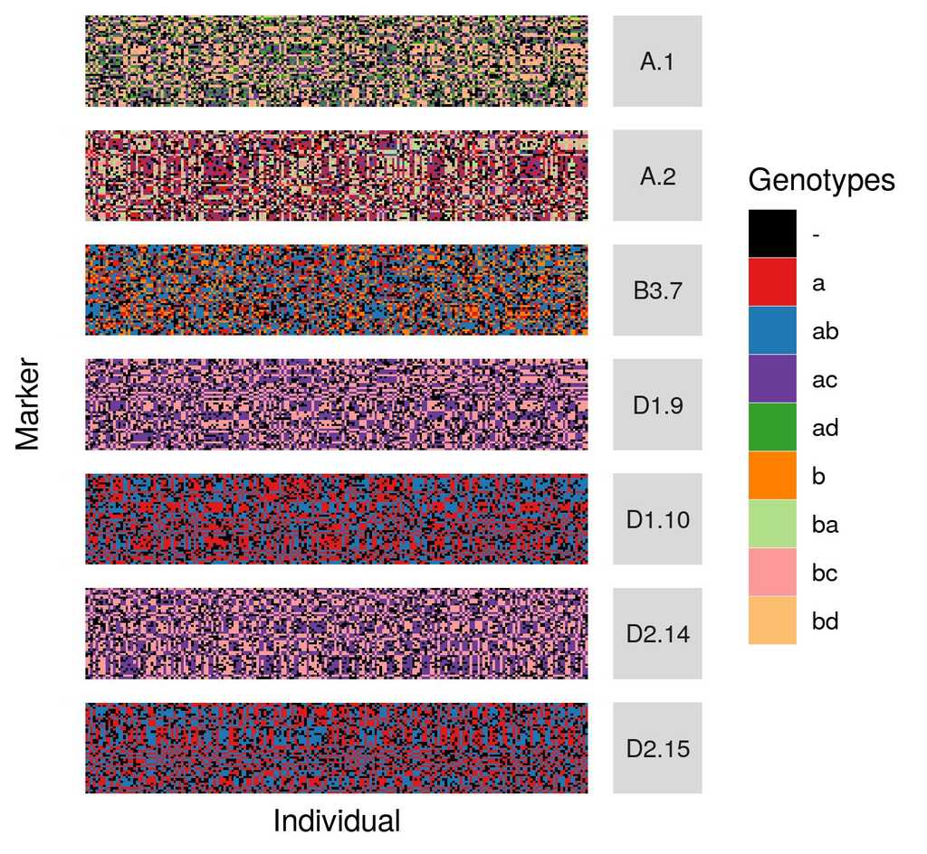

```r
simParallel <- read_onemap(system.file(package = "onemap", "extdata/simParall_out.raw"))
plot(simParallel, all=FALSE)
```

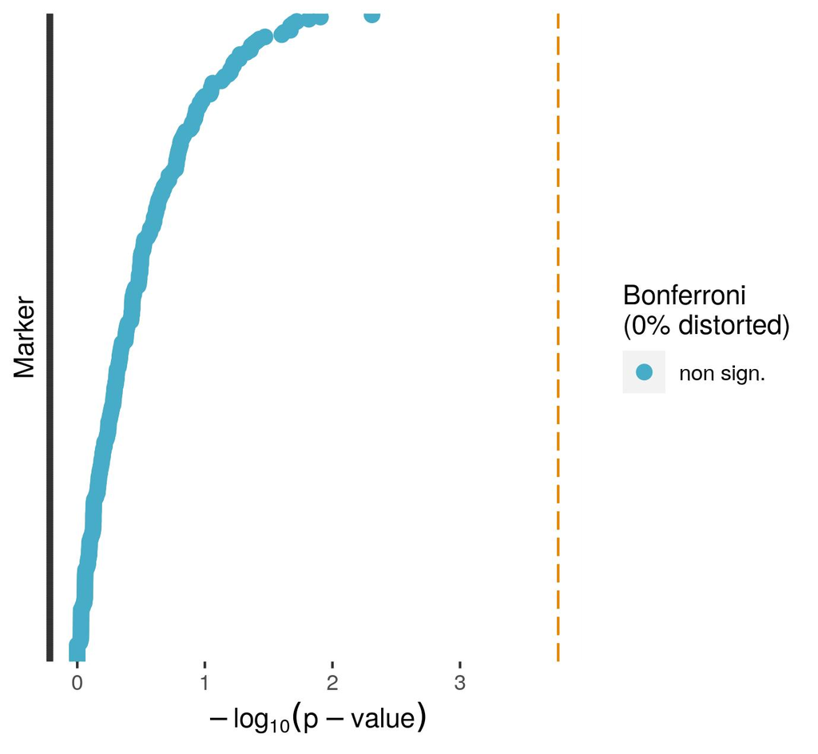

```r
# Calculates two-points recombination fractions
twopts <- rf_2pts(simParallel)
seq_all <- make_seq(twopts, "all")
# There are no redundant markers
find_bins(simParallel)
# There are no distorted markers
p <- plot(test_segregation(simParallel))
```

To prepare the data with a defined bach size, we use the function `pick_batch_sizes`. It selects a batch size that splits the data into even groups. Argument `size` defines the batch size next to which an optimum size will be searched. `overlap` defines the number of markers that overlap between the present batch and next. This is used because pre-defined phases at these overlap markers in the present batch are used to start the HMM in the next batch. The `around` argument defines how much the function can vary around the defined number in `size` to search for the optimum batch size.

Some aspects should be considered to define these arguments because if the batch size were set too high, there would be less gain in execution time. If the overlap size were too small, phases would be incorrectly estimated, and large gaps would appear in the map, inflating its size. In practice, these values will depend on many factors such as population size, marker quality, and species. BatchMap authors recommended trying several configurations on a subset of data and select the best performing one.

```r
batch_size <- pick_batch_sizes(input.seq = seq_all,
                               size = 80,
                               overlap = 30,
                               around = 10)
batch_size
```

## Speed up two-points ordering approaches

To use parallelized approach you just need to include the arguments when using the functions:

```r
# Without parallelization
rcd_map <- rcd(input.seq = seq_all)
# With parallelization
rcd_map_par <- rcd(input.seq = seq_all,
                   phase_cores = 4,
                   size = batch_size,
                   overlap = 30)
```

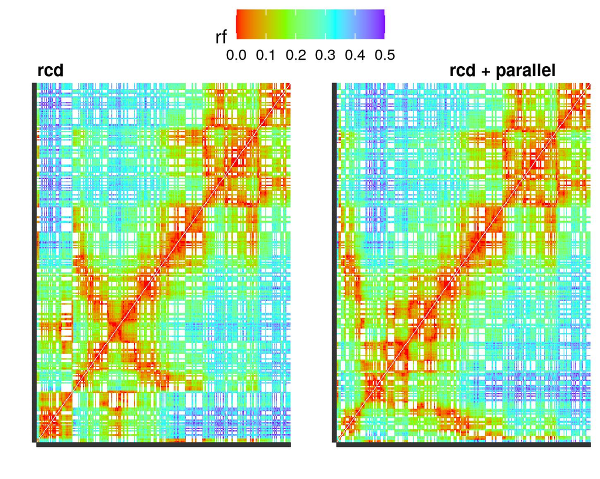

```r
# Without parallelization
record_map <- record(input.seq = seq_all)
# With parallelization
record_map_par <- record(input.seq = seq_all,
                         phase_cores = 4,
                         size = batch_size,
                         overlap = 30)
```

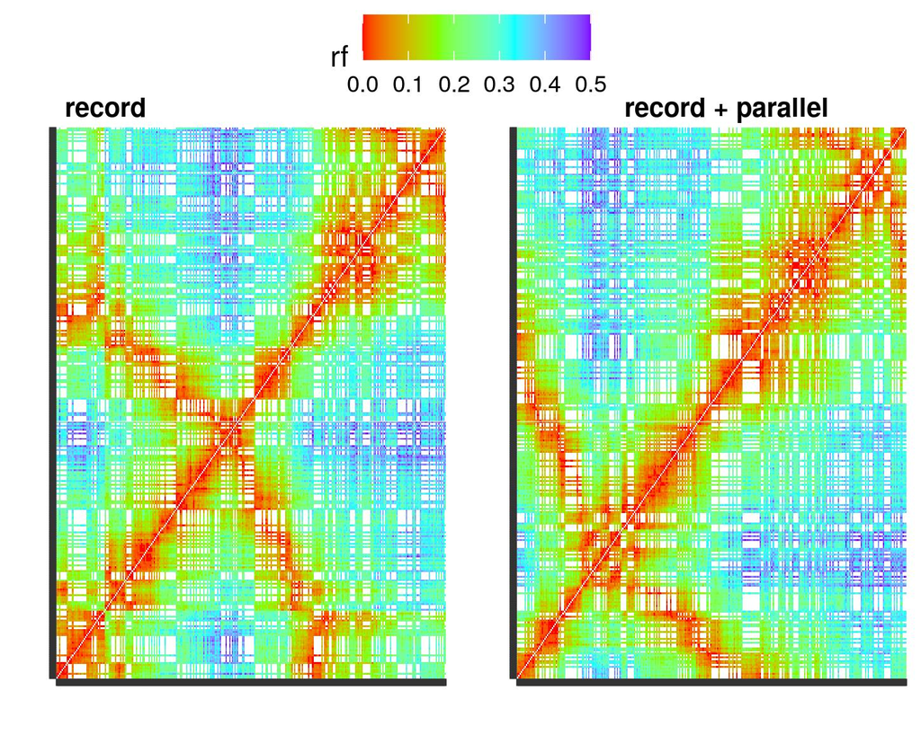

```r
# Without parallelization
ug_map <- ug(input.seq = seq_all)
# With parallelization
ug_map_par <- ug(input.seq = seq_all,
                 phase_cores = 4,
                 size = batch_size,
                 overlap = 30)
```

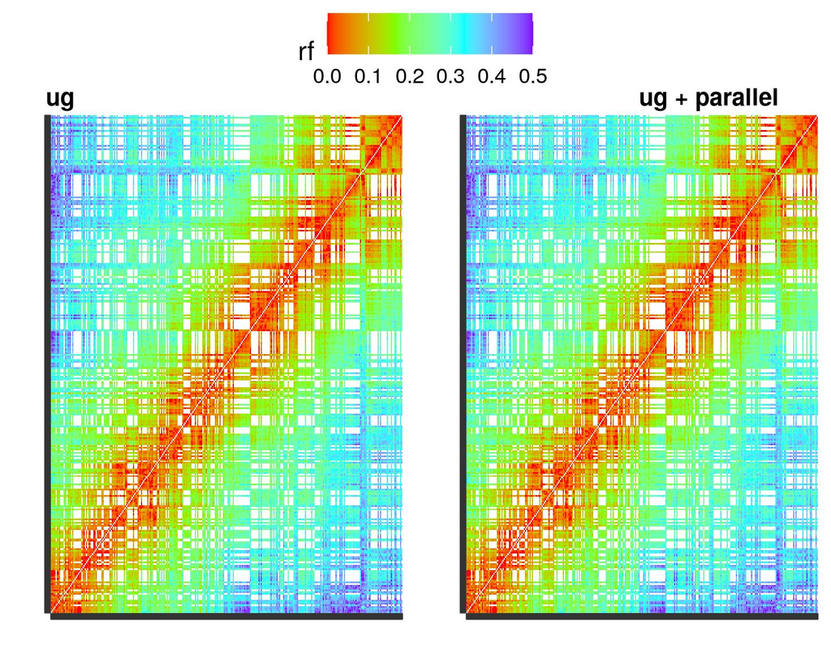

## Speed up mds_onemap

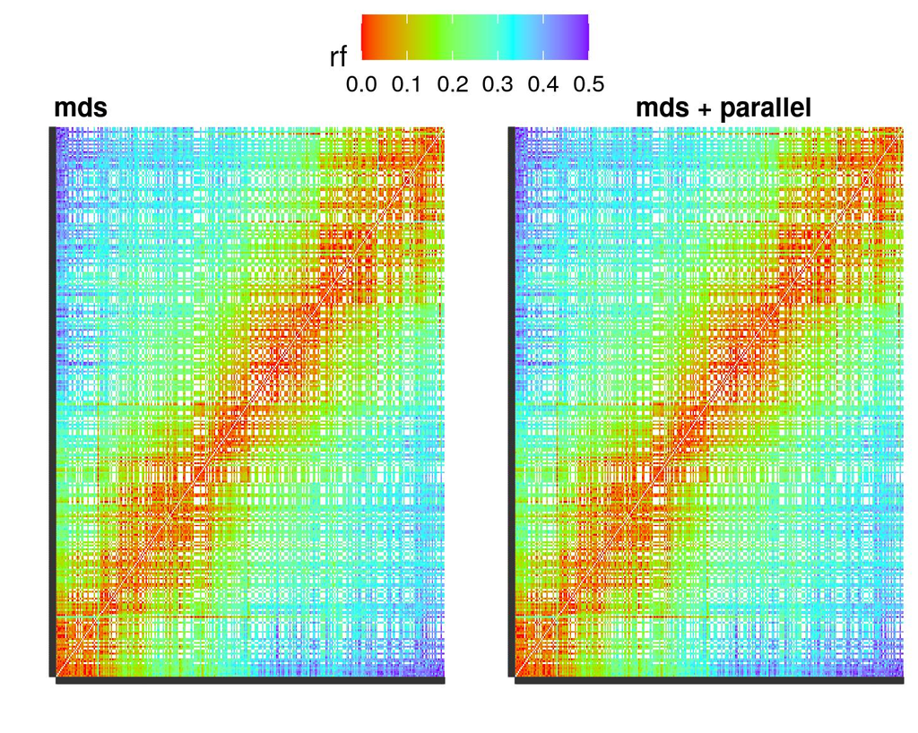

```r
# Without parallelization ok
map_mds <- mds_onemap(input.seq = seq_all)
# With parallelization
map_mds_par <- mds_onemap(input.seq = seq_all,
                          phase_cores = 4,
                          size = batch_size,
                          overlap = 30)
```

## Speed up map estimation for an arbitrary order (map function)

Because we simulate this dataset, we know the correct order. We can use `map_overlapping_batches` to estimate genetic distance in this case. This is equivalent to `map`, but with a parallelized process.

Similarly, with `map`, using argument `rm_unlinked = TRUE` the function will return a vector with marker numbers without the problematic marker. To repeat the analysis removing automatically all problematic markers use `map_avoid_unlinked`:

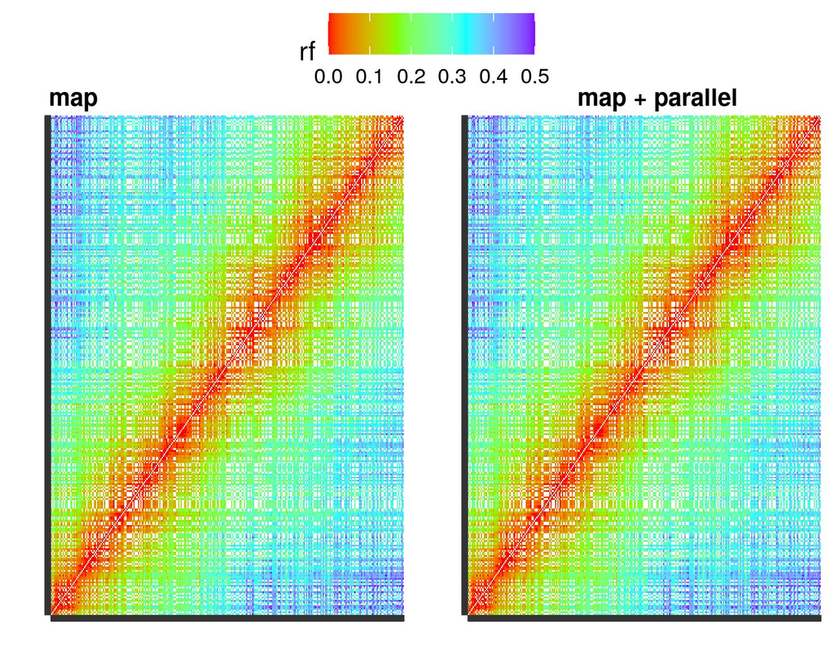

```r
# Without parallelization
batch_map <- map_avoid_unlinked(input.seq = seq_all)
# With parallelization
batch_map_par <- map_avoid_unlinked(input.seq = seq_all,
                                    size = batch_size,
                                    phase_cores = 4,
                                    overlap = 30)
```

As you can see in the above maps, heuristic ordering algorithms do not return an optimal order result, mostly if you don’t have many individuals in your population. Because of the erroneous order, generated map size is not close to the simulated size (100 cM) and their heatmaps don’t present the expected color pattern. Two of them get close to the color pattern, they are the ug and the MDS method. They present the right global ordering but not local. If you have a reference genome, you can use its position information to rearrange the local order.

# Export estimated parents haplotypes (new!)

In the older version, users could only access the estimated linkage phase by observing the print in the console:

```r
CHR3_final
```

```
#>
#> Printing map:
#>
#> Markers           Position           Parent 1       Parent 2
#>
#> 27 M27                0.00           b |  | o       a |  | a
#> 16 M16               11.76           a |  | a       b |  | o
#> 20 M20               22.94           a |  | b       c |  | d
#>  4 M4                35.71           a |  | o       o |  | b
#> 21 M21               49.41           o |  | o       a |  | b
#> 23 M23               55.24           a |  | o       a |  | o
#> 48 SNP21             67.50           a |  | b       a |  | a
#>  9 M9                74.02           a |  | b       a |  | a
#> 46 SNP18             80.43           a |  | b       a |  | a
#> 45 SNP17             95.40           a |  | b       a |  | a
#> 47 SNP20            119.95           a |  | b       a |  | a
#> 50 SNP23            158.43           a |  | b       b |  | a
#> 24 M24              163.43           a |  | b       b |  | a
#> 49 SNP22            166.72           a |  | b       b |  | a
#> 52 SNP25            171.62           a |  | b       b |  | a
#> 51 SNP24            182.56           a |  | b       b |  | a
#>
#> 16 markers            log-likelihood: -811.5279
```

Now, you can export this information into a data.frame using:

```r
(parents_haplot <- parents_haplotypes(CHR3_final))
```

```
#>        group mk.number mk.names      dist P1_1 P1_2 P2_1 P2_2
#> 1  Group - 1        27      M27   0.00000    b    o    a    a
#> 2  Group - 1        16      M16  11.75801    a    a    b    o
#> 3  Group - 1        20      M20  22.93778    a    b    c    d
#> 4  Group - 1         4       M4  35.70756    a    o    o    b
#> 5  Group - 1        21      M21  49.40658    o    o    a    b
#> 6  Group - 1        23      M23  55.24441    a    o    a    o
#> 7  Group - 1        48    SNP21  67.49802    a    b    a    a
#> 8  Group - 1         9       M9  74.02260    a    b    a    a
#> 9  Group - 1        46    SNP18  80.43325    a    b    a    a
#> 10 Group - 1        45    SNP17  95.40132    a    b    a    a
#> 11 Group - 1        47    SNP20 119.95322    a    b    a    a
#> 12 Group - 1        50    SNP23 158.42672    a    b    b    a
#> 13 Group - 1        24      M24 163.43246    a    b    b    a
#> 14 Group - 1        49    SNP22 166.72021    a    b    b    a
#> 15 Group - 1        52    SNP25 171.61828    a    b    b    a
#> 16 Group - 1        51    SNP24 182.55630    a    b    b    a
```

```r
write.table(parents_haplot, "parents_haplot.txt")
```

The data.frame contains: group ID (group), marker number (mk.number) and names (mk.names), position in centimorgan (dist) and parents haplotypes (P1_1, P1_2, P2_1, P2_2).

You can also obtain a data.frame with a list of sequences and personalize the group names:

```r
parents_haplotypes(CHR2_final,CHR3_final, group_names=c("CHR2","CHR3"))
```

```
#>    group mk.number mk.names      dist P1_1 P1_2 P2_1 P2_2
#> 1   CHR2        43    SNP14   0.00000    a    b    a    a
#> 2   CHR2        22      M22  13.50513    a    b    a    a
#> 3   CHR2         7       M7  23.08429    a    a    a    b
#> 4   CHR2        18      M18  64.51343    a    b    c    d
#> 5   CHR2         8       M8  70.19895    b    a    b    a
#> 6   CHR2        13      M13  72.86392    a    o    a    o
#> 7   CHR2        44    SNP16  78.74250    b    a    b    a
#> 8   CHR3        27      M27   0.00000    b    o    a    a
#> 9   CHR3        16      M16  11.75801    a    a    b    o
#> 10  CHR3        20      M20  22.93778    a    b    c    d
#> 11  CHR3         4       M4  35.70756    a    o    o    b
#> 12  CHR3        21      M21  49.40658    o    o    a    b
#> 13  CHR3        23      M23  55.24441    a    o    a    o
#> 14  CHR3        48    SNP21  67.49802    a    b    a    a
#> 15  CHR3         9       M9  74.02260    a    b    a    a
#> 16  CHR3        46    SNP18  80.43325    a    b    a    a
#> 17  CHR3        45    SNP17  95.40132    a    b    a    a
#> 18  CHR3        47    SNP20 119.95322    a    b    a    a
#> 19  CHR3        50    SNP23 158.42672    a    b    b    a
#> 20  CHR3        24      M24 163.43246    a    b    b    a
#> 21  CHR3        49    SNP22 166.72021    a    b    b    a
#> 22  CHR3        52    SNP25 171.61828    a    b    b    a
#> 23  CHR3        51    SNP24 182.55630    a    b    b    a
```

# Export estimated progeny haplotypes (new!)

Function `progeny_haplotypes` generates a data.frame with progeny phased haplotypes estimated by `OneMap` HMM. For progeny, the HMM results in probabilities for each possible genotype, then the generated data.frame contains all possible genotypes. If `most_likely = TRUE`, the most likely genotype receives 1 and the rest 0 (if there are two most likely both receive 0.5), if `most_likely = FALSE` genotypes probabilities will be according to the HMM results. You can choose which individual to be evaluated in `ind`. The data.frame is composed by the information: individual (ind) and group (grp) ID, position in centimorgan (pos), progeny homologs (homologs), and from each parent the allele came (parents).

```r
(progeny_haplot <- progeny_haplotypes(CHR2_final, most_likely = TRUE, ind = c(1,2), group_names = "CHR2_final"))
```

```
#>     ind marker        grp      pos prob parents parents.homologs allele
#> 1  IND1  SNP14 CHR2_final  0.00000    0      P1               H1  P1_H1
#> 2  IND1    M22 CHR2_final 13.50513    0      P1               H1  P1_H1
#> 3  IND1     M7 CHR2_final 23.08429    0      P1               H1  P1_H1
#> 4  IND1    M18 CHR2_final 64.51343    1      P1               H1  P1_H1
#> 5  IND1     M8 CHR2_final 70.19895    1      P1               H1  P1_H1
#> 6  IND1    M13 CHR2_final 72.86392    1      P1               H1  P1_H1
#> 7  IND1  SNP16 CHR2_final 78.74250    1      P1               H1  P1_H1
#> 8  IND2  SNP14 CHR2_final  0.00000    1      P1               H1  P1_H1
#> 9  IND2    M22 CHR2_final 13.50513    1      P1               H1  P1_H1
#> 10 IND2     M7 CHR2_final 23.08429    1      P1               H1  P1_H1
#> 11 IND2    M18 CHR2_final 64.51343    1      P1               H1  P1_H1
#> 12 IND2     M8 CHR2_final 70.19895    1      P1               H1  P1_H1
#> 13 IND2    M13 CHR2_final 72.86392    1      P1               H1  P1_H1
#> 14 IND2  SNP16 CHR2_final 78.74250    1      P1               H1  P1_H1
```

[output cut: 42 more lines]

You can also have a view of progeny estimated haplotypes using `plot`. It shows which markers came from each parent’s homologs. `position` argument defines if haplotypes will be plotted by homologs (`stack`) or alleles (`split`). `split` option is a good way to view the likelihoods of each allele.

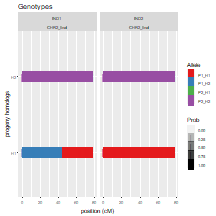

```r
plot(progeny_haplot, position = "stack")
```

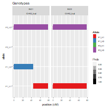

[session information not shown]

```r
plot(progeny_haplot, position = "split")
```

# References

Buetow, K. H., Chakravarti, A. Multipoint gene mapping using seriation. I. General methods. *American Journal of Human Genetics* 41, 180-188, 1987.

Doerge, R.W. Constructing genetic maps by rapid chain delineation. *Journal of Agricultural Genomics* 2, 1996.

Mollinari, M., Margarido, G. R. A., Vencovsky, R. and Garcia, A. A. F. Evaluation of algorithms used to order markers on genetics maps. *Heredity* 103, 494-502, 2009.

Schiffthaler, B., Bernhardsson, C., Ingvarsson, P. K., & Street, N. R. BatchMap: A parallel implementation of the OneMap R package for fast computation of F1 linkage maps in outcrossing species. *PLoS ONE*, 12(12), 1–12, 2017.

Tan, Y., Fu, Y. A novel method for estimating linkage maps. *Genetics* 173, 2383-2390, 2006.

Van Os H, Stam P, Visser R.G.F., Van Eck H.J. RECORD: a novel method for ordering loci on a genetic linkage map. *Theor Appl Genet* 112, 30-40, 2005.

Voorrips, R.E. MapChart: software for the graphical presentation of linkage maps and QTLs. *Journal of Heredity* 93, 77-78, 2002.

Voorrips, R. E., Maliepaard, C. A. The simulation of meiosis in diploid and tetraploid organisms using various genetic models. *BMC Bioinformatics*, 13(1), 248, 2012.

Wu, R., Ma, C.X., Painter, I. and Zeng, Z.-B. Simultaneous maximum likelihood estimation of linkage and linkage phases in outcrossing species. *Theoretical Population Biology* 61, 349-363, 2002a.

Wu, R., Ma, C.-X., Wu, S. S. and Zeng, Z.-B. Linkage mapping of sex-specific differences. *Genetical Research* 79, 85-96, 2002b.